# Final Project EDA

XI KANG, MINGZE YAN

4/25/2021

```r
## Load Packages, Set Seed
library(tidyverse)
library(tidymodels)
library(skimr)
library(naniar)
library(kableExtra)
library(corrplot)
library(corrr)
set.seed(123)
```

## Introduction

This is the EDA section for the Stat 301-3 final project. The goal of this project is to predict one’s risk for stroke through a classification approach.

Based on the information from the [World Health Organization (WHO)](https://dx.doi.org/10.2471/BLT.16.181636), stroke is the second leading cause of death and the third leading cause for disability. Nevertheless, effective prevention actions can be applied to reduce the fatal effects of this medical emergency and lower the risk for mortality and disability. Thus, to provide targeted support and effective prevention strategies, it is crucial to identify the risks for stroke based on common factors related to one’s lifestyle or chronic health conditions.

Thus, driven by the incentives mentioned above, our project focuses on predicting the risk for stroke based on input parameters about one’s lifestyle and health status. The research question of this project is a predictive classification question.

## Initial Overview

### Data Source

The dataset used by this project is the “Stroke Prediction Dataset” provided on [Kaggle](https://www.kaggle.com/fedesoriano/stroke-prediction-dataset). We first loaded in the raw dataset and cleaned the names. The initial data tidying process it completed in the FinalProject_tidy_data.r file. The code used is presented below:

```r
## Load raw dataset ----
stroke_dat <-
  read_csv("data/unprocessed/healthcare-dataset-stroke-data.csv") %>%
  clean_names() %>%
  mutate(
    gender = factor(gender),
    ever_married = factor(ever_married),
    work_type = factor(work_type),
    residence_type = factor(residence_type),
    smoking_status = factor(smoking_status),
    stroke = factor(stroke, levels = c(1, 0),
                    labels = c("Yes", "No")),
    hypertension = factor(hypertension, levels = c(1, 0),
                          labels = c("Yes", "No")),
    heart_disease = factor(heart_disease, levels = c(1, 0),
                           labels = c("Yes", "No")),
    bmi = as.numeric(bmi)
  ) %>%
  select(-id)

## initial skimming ----
skim_without_charts(stroke_dat)

## save processed data ----
stroke_dat %>%
  write_rds("data/processed/stroke_data.rds")
```

### Dataset Overview

Using methods from `skimr`, we noticed that the original dataset contains 5110 rows and 12 columns. For the convenience of the later processes, we first turned the categorical variables `gender`, `ever_married`, `work_type`, `residence_type`, and `smoking_status` into factors. The outcome variable `stroke` and variables `hypertension` and `heart_disease` were initially identified as numeric variables, but they should be categorical. Thus, we turned them into a factors. Since `id` will not be used as a categorical variable, we removed it from the original dataset.

After initial tidying, we loaded in the processed data and performed a train-test split, stratified by the outcome variable `stroke`. We used 70% of the data for training and 30% for testing:

```r
stroke_data <- readRDS("data/processed/stroke_data.rds")

## split data ----
stroke_split <- initial_split(stroke_data, prop = 0.7, strata = stroke)
stroke_train <- training(stroke_split)
stroke_test <- testing(stroke_split)
```

The EDA section will be performed using the training set data, `stroke_train`.

After the split, we first obtained an overview on the training set using the methods from the `skimr` package. We noticed that the training set contains 11 variables, and 3577 observations. Among them 8 variables are factors and 3 variables are numeric. The outcome variable `stroke` is a categorical variable of type factor.

### Missing Data

During the initial skimming, we noticed that only one variable `bmi` contains missing values. To obtain a wholistic overview on the general situation of missingness in the training data, we created a plot showing the amount of missing data in each column using the `vis_miss()` function from `naniar`:

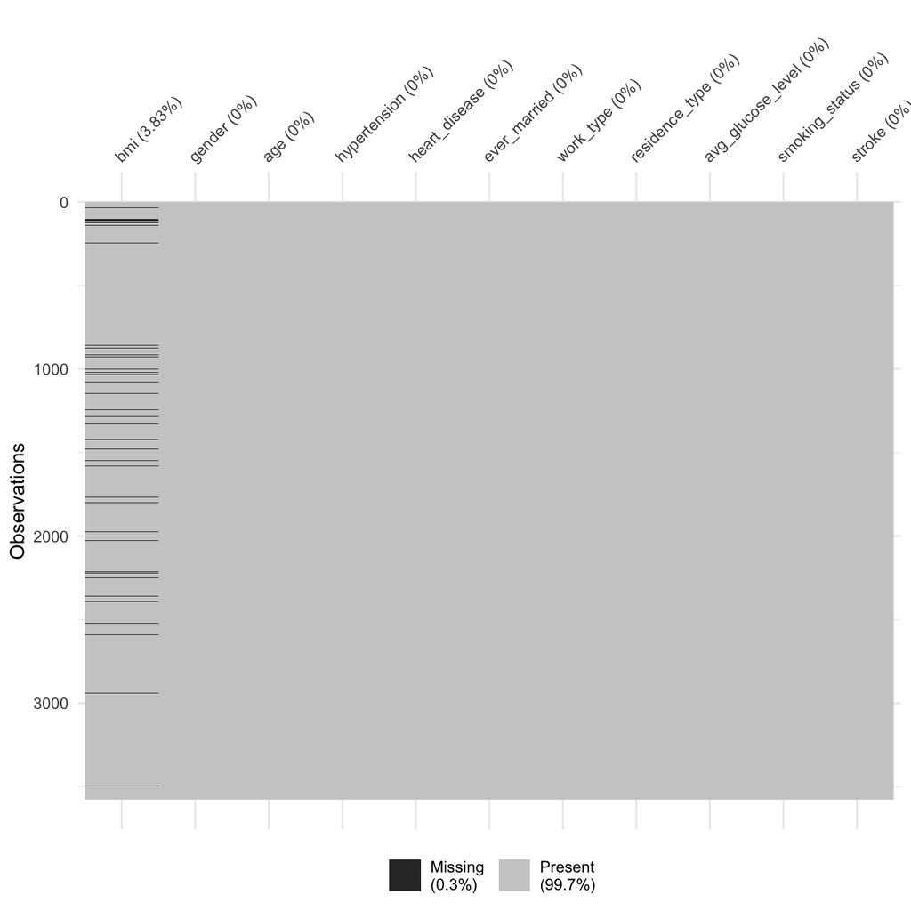

```r
# overview of missingness
stroke_train %>%
  vis_miss(sort_miss = TRUE)
```

As shown, within the 11 columns in the dataset, there is only column `bmi` with missing data. The response variable `stroke` does not have any missing values. To clearly present the percentage of missingness for each variable, we created the table below using `miss_var_summary()`, and we highlighted the rows for the variable with missing value in blue:

```r
# overview table
stroke_train %>%
  miss_var_summary() %>%
  kbl() %>%
  kable_classic() %>%
  kable_styling(bootstrap_options = c("striped", "hover")) %>%
  row_spec(1, color = "white",
           background = "blue") %>%
  kableExtra::footnote(
    general = "Number and Percentage of Missing Values in Each Variable"
  )
```

| variable | n_miss | pct_miss |
| --- | --- | --- |
| bmi | 137 | 3.830025 |
| gender | 0 | 0.000000 |
| age | 0 | 0.000000 |
| hypertension | 0 | 0.000000 |
| heart_disease | 0 | 0.000000 |
| ever_married | 0 | 0.000000 |
| work_type | 0 | 0.000000 |
| residence_type | 0 | 0.000000 |
| avg_glucose_level | 0 | 0.000000 |
| smoking_status | 0 | 0.000000 |
| stroke | 0 | 0.000000 |

Note:  
Number and Percentage of Missing Values in Each Variable

As shown, `bmi` is the only variable with missing values and its percentage of missingness is about 4%. Since the degree of missingness is very low, we plan to impute `bmi` using bagged tree imputation.

## Essential Findings

### Outcome variable

We first performed a univariate investigation of the response variable `stroke`. The barchart below provides an overview on the distribution of `stroke` in the training set:

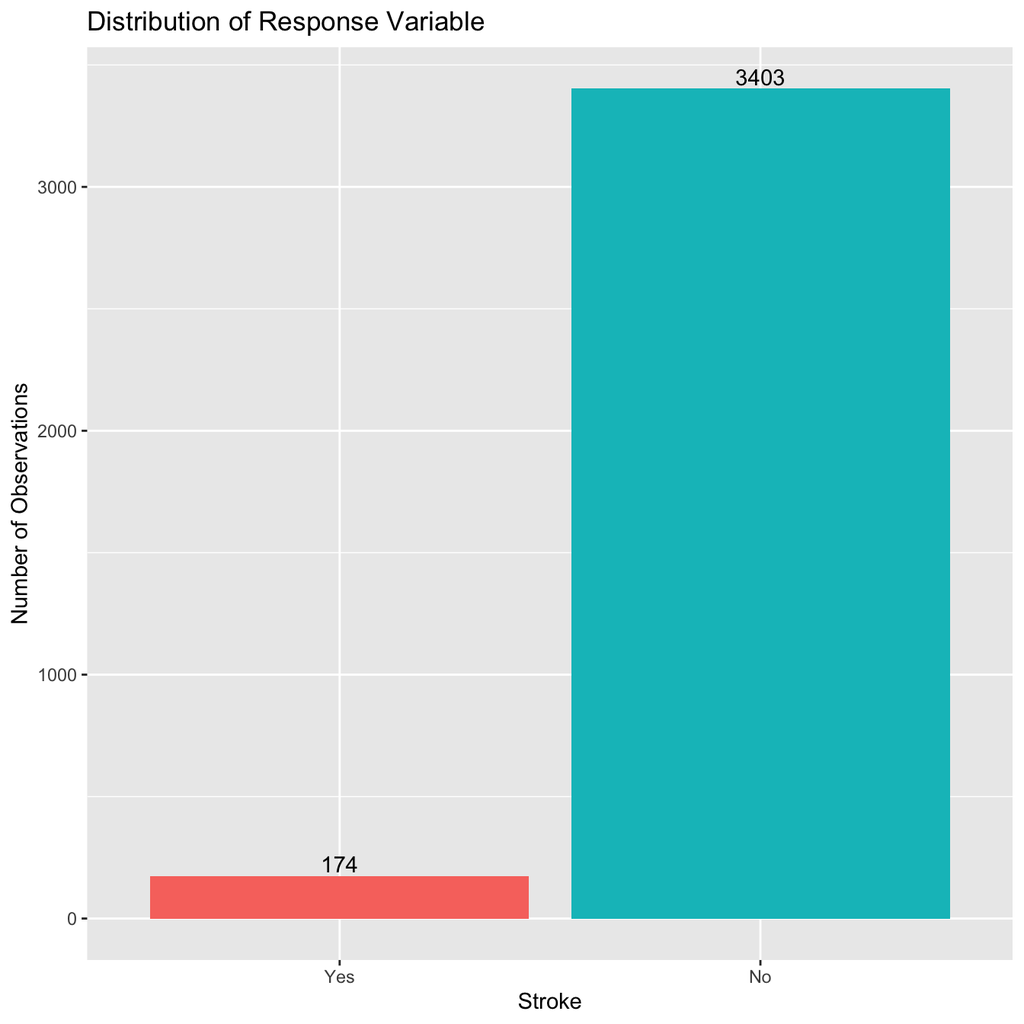

```r
# plot
stroke_train %>%
  ggplot(aes(stroke, fill = stroke)) +
  geom_bar(show.legend = FALSE) +
  labs(
    x = "Stroke",
    y = "Number of Observations",
    title = "Distribution of Response Variable"
  ) +
  geom_text(
    aes(label = ..count..),
    stat = "count",
    position = position_dodge(width = 0.9),
    vjust = -0.25
  )
```

### Numeric Predictors

#### Correlation among Predictors

We used a correlation plot to explore the correlation among numeric predictors. Since the degree of missingness is very low for `bmi` we temporarily dropped the `NA` in plotting to avoid errors.

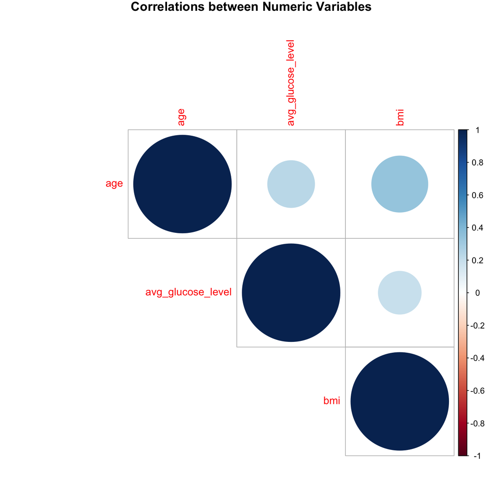

```r
# correlation plot
stroke_train %>%
  select(age, avg_glucose_level, bmi) %>%

  drop_na() %>%
  # compute correlation matrix
  cor() %>%
  # visualize
  corrplot(type = "upper",
           title = "Correlations between Numeric Variables",
           mar = c(0, 0, 1, 0))
```

As shown, there is no near-perfect collinearity between any pair of number predictors. All three variables are positively related to each other. A table showing the correlation between the numeric predictors is also presented below:

```r
# correlation between predictors
stroke_train %>%
  select(age, avg_glucose_level, bmi) %>%
  drop_na() %>%
  # compute correlation matrix
  correlate() %>%
  # turn into a tibble
  stretch() %>%
  rename("correlation" = "r") %>%
  arrange(desc(correlation)) %>%
  # temporary var `row_id` to help removing repeated info
  mutate(row_id = row_number()) %>%
  # filter out even rows
  drop_na() %>%
  filter(row_id %% 2 == 0) %>%
  # remove temporary var
  select(-row_id) %>%
  kbl() %>%
  kable_classic()
```

| x | y | correlation |
| --- | --- | --- |
| bmi | age | 0.3306132 |
| avg_glucose_level | age | 0.2311689 |
| bmi | avg_glucose_level | 0.1930028 |

#### `age` predictor

In common knowledge, age is often closely related to one’s risk for stroke. Also, knowing the distribution of variable `age` in this dataset can help us understand the age range of population for which the result of this project is applicable. Thus, we plotted the distribution of `age` in the training set:

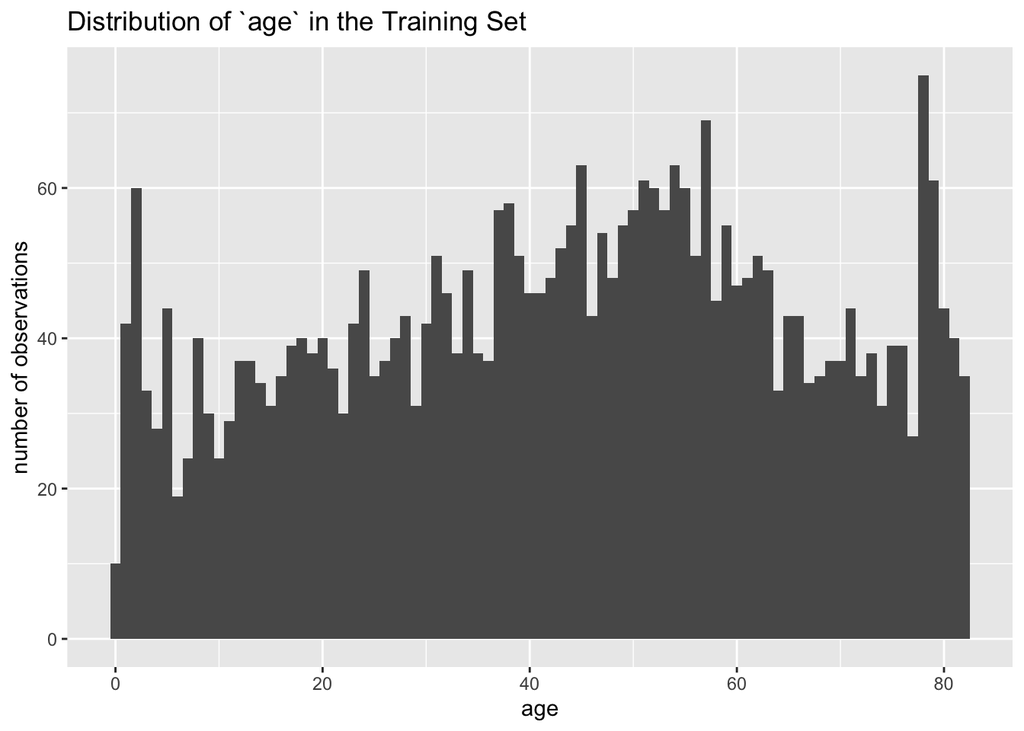

```r
# distribution of age
ggplot(stroke_train, aes(age)) +
  geom_histogram(binwidth = 1) +
  labs(
    x = "age",
    y = "number of observations",
    title = "Distribution of `age` in the Training Set"
  )
```

As shown, the distribution of `age` is about normal. Also, the observations range from 0 to 80-year old without any gaps in between. There are two abrupt peaks: one slightly below 10 and one slightly above 75, suggesting that there are more observations with these two age values. However, no obvious outliers are observed.

We then explored the relation between `age` and the outcome variable `stroke` using the boxplot below:

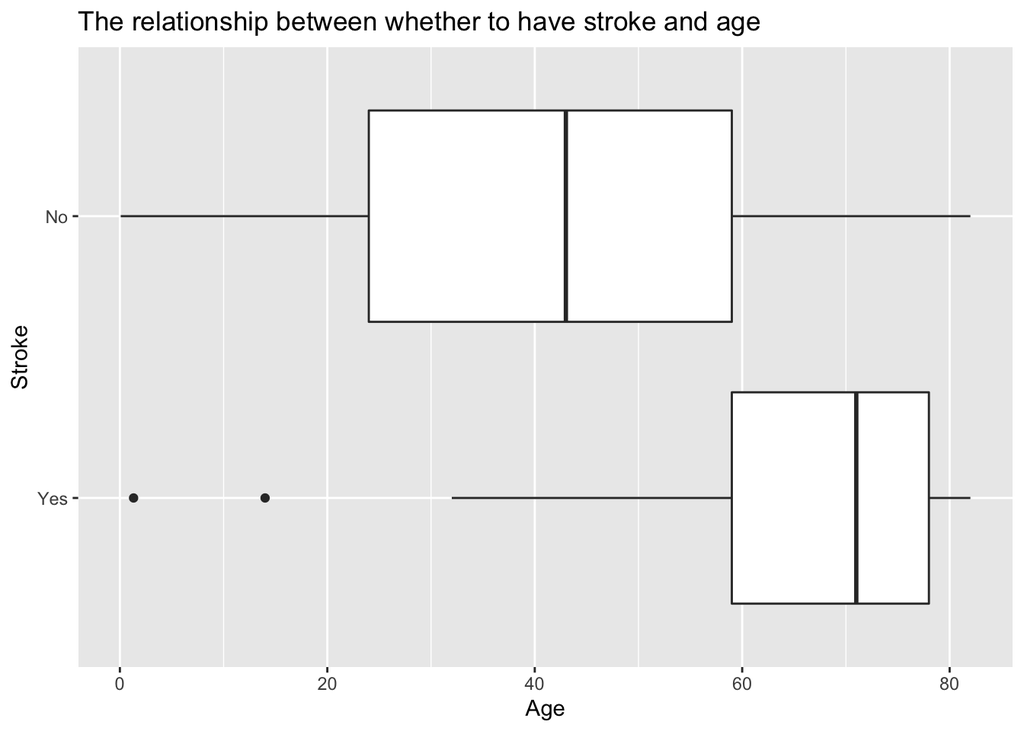

```r
# relation between `age` and `stroke`
ggplot(stroke_train, aes(age, stroke)) +
  geom_boxplot() +
  labs(
     x = "Age",
     y = "Stroke",
     title = "The relationship between whether to have stroke and age"
  )
```

##### Relation between `age` and `heart_disease`

Age is often considered as an important factor determing one’s risk for heart disease. Thus, we used boxplot to explore the relation between `age` and `heart_disease` in the training set:

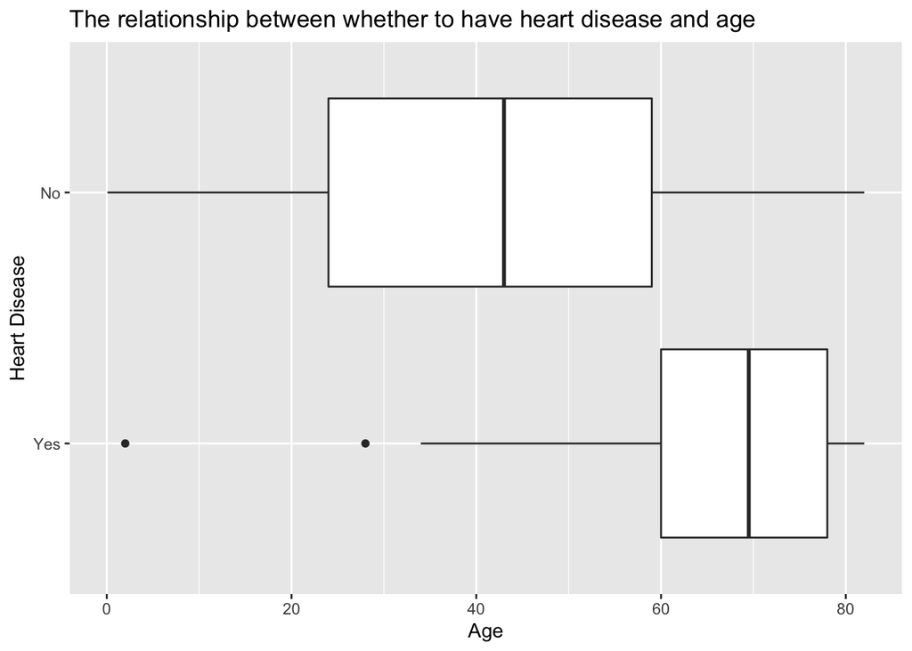

```r
# relation between `age` and `heart_disease`
ggplot(stroke_train, aes(age, heart_disease)) +
  geom_boxplot() +
  labs(
     x = "Age",
     y = "Heart Disease",
     title = "The relationship between whether to have heart disease and age"
  )
```

As shown, the distribution of `age` is severely left-skewed for `heart_disease` with level `Yes`. This visualization suggests the correlation between `heart_disease` and `age`. Among the sample population from which the data was obtained, individual older in age are more likely to get heart disease.

#### Skewness in `avg_glucose_level` and `bmi`

We also explored the distribution of `avg_glucose_level` and `bmi` in the training set:

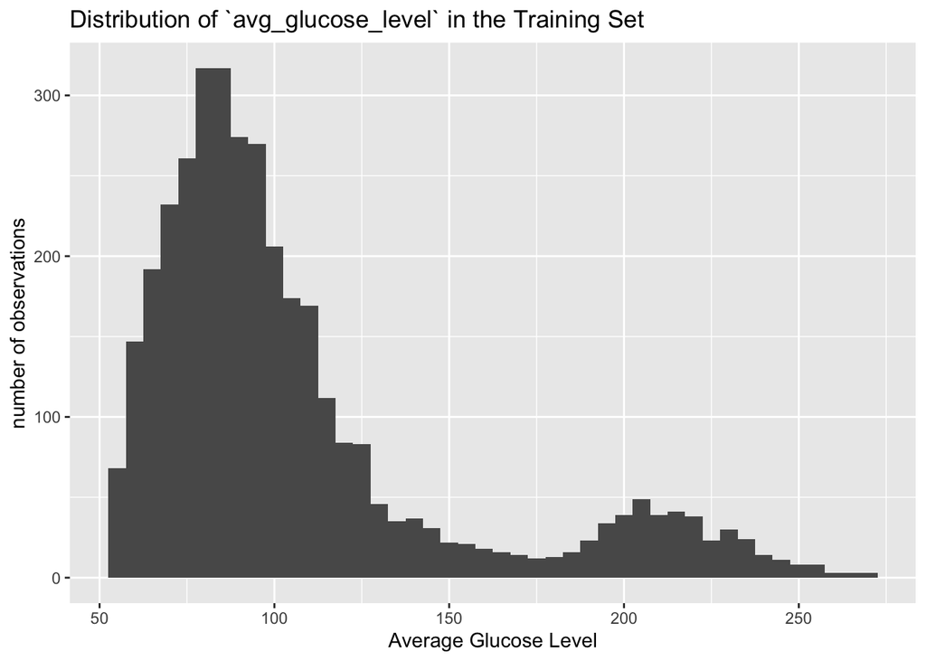

```r
# distribution of avg_glucose_level
ggplot(stroke_train, aes(avg_glucose_level)) +
  geom_histogram(binwidth = 5) +
  labs(
    x = "Average Glucose Level",
    y = "number of observations",
    title = "Distribution of `avg_glucose_level` in the Training Set"
  )
```

As shown, the distribution of `avg_glucose_level` is severely right-skewed. With the number of observations decreasing abruptly above 110. This result suggests that there are fewer observations with `avg_glucose_level` above 110. This result makes sense, considering the online resources suggest that a normal blood glucose level ranges from 80 to 140. An blood glucose level in the range 140-200 should be considered as pre-diabetes. Thus, we can imply from the plot that,in the training set, there are more observations with normal blood sugar level than observations with pre-diabetes conditions.

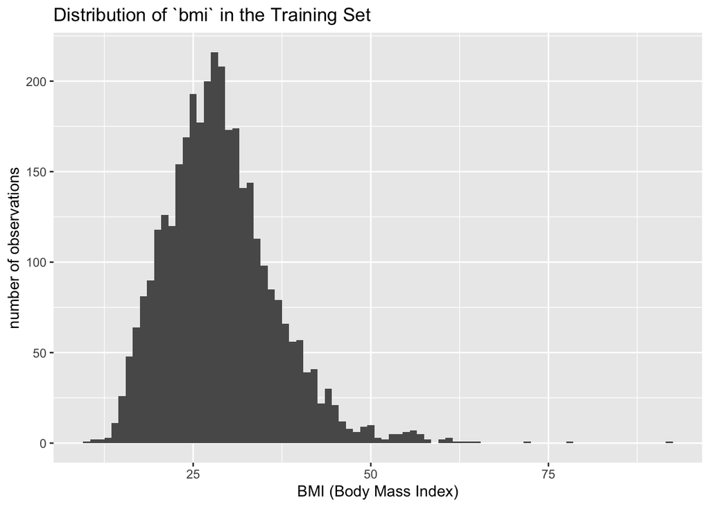

```r
# distribution of bmi
ggplot(stroke_train, aes(bmi)) +
  geom_histogram(binwidth = 1) +
  labs(
    x = "BMI (Body Mass Index)",
    y = "number of observations",
    title = "Distribution of `bmi` in the Training Set"
  )
```

As shown, the distribution of `bmi` in the training set is also severly right-skewed. There are near-zero observations for `bmi` values above 50 and values below 10. From online resources, we learned that the normal range for BMI value is 18.5 to 25. BMI values less than 18.5 suggest underweight. Values from 25.0 to 30 suggests overweight range, and BMI above 30 suggests obesity. Thus, it makes sense for the distribution of `bmi` values to peak around the range from 25 to 30.

Based on the observed skewness, we decided to log-transform variables `avg_glucose_level` and `bmi` in creating the recipes later.

### Categorical Predictors

#### Class Imbalance in `ever_married`

In exploring the categorical predictors, we noticed that there is class imbalance in the distributions of `ever_married`.

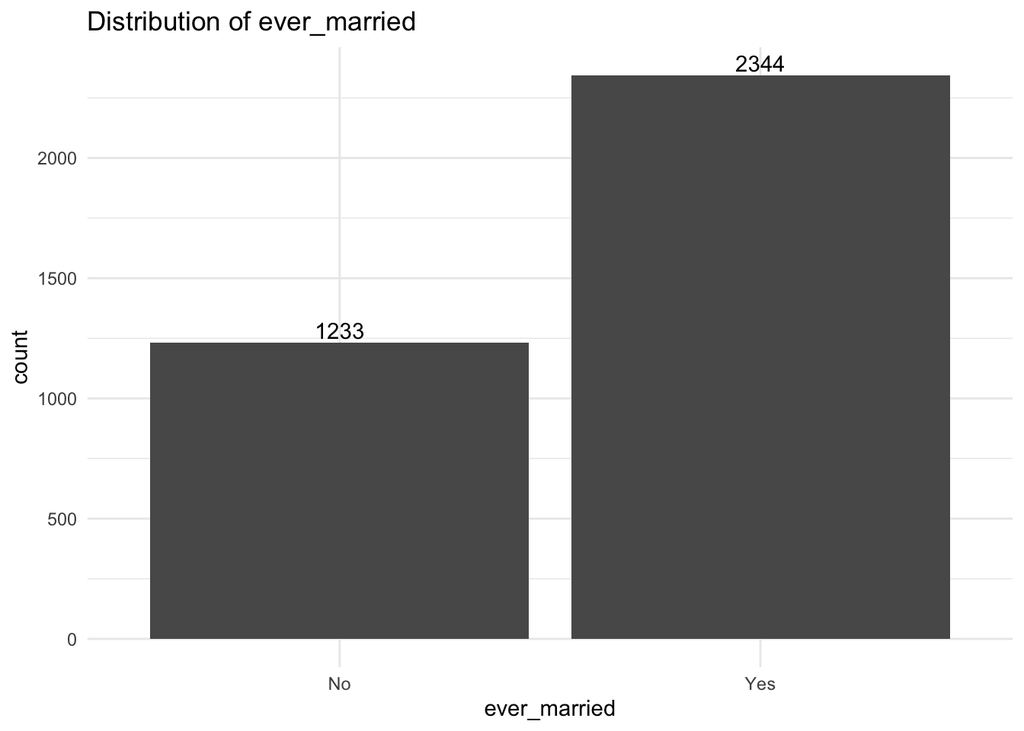

```r
ggplot(stroke_train, aes(x = ever_married)) +
  geom_bar() +
  geom_text(
    aes(label = ..count..),
    stat = "count",
    position = position_dodge(width = 0.9),
    vjust = -0.25,
    hjust = 0.5
  ) +
  labs(
    title = "Distribution of ever_married"
  ) +
  theme_minimal()
```

As shown, there are approximately 1100 more patients having married before. If encountering problem in resampling and cross-validation, we might need to consider using random under-sampling or over-sampling.

#### Less Occurring Values

Observing the distribution of the multi-level categorical variables, we noticed that some variables have severely less occuring values that might cause problems in the later modeling process. Specific recipe steps will be applied based on the situation.

##### Distribution of `gender`

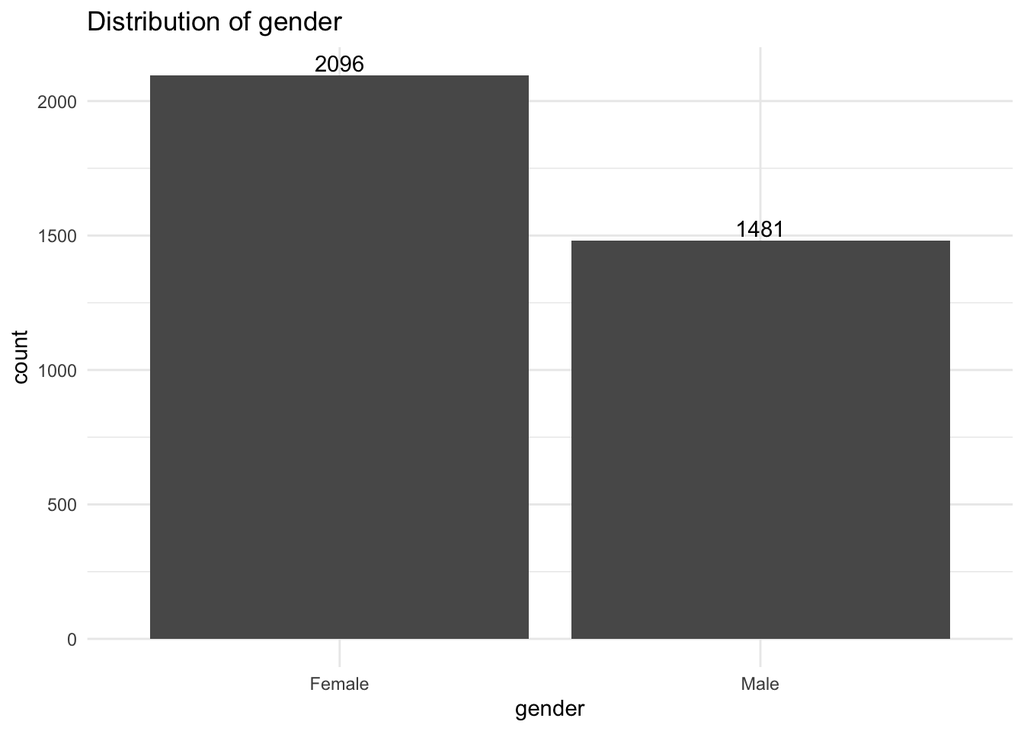

```r
ggplot(stroke_train, aes(x = gender)) +
  geom_bar() +
  geom_text(
    aes(label = ..count..),
    stat = "count",
    position = position_dodge(width = 0.9),
    vjust = -0.25,
    hjust = 0.5
  ) +
  labs(
    title = "Distribution of gender"
  ) +
  theme_minimal()
```

##### Distribution of `smoking_status`

There is also obvious difference in the number of observations in each level or variable `smoking_status`:

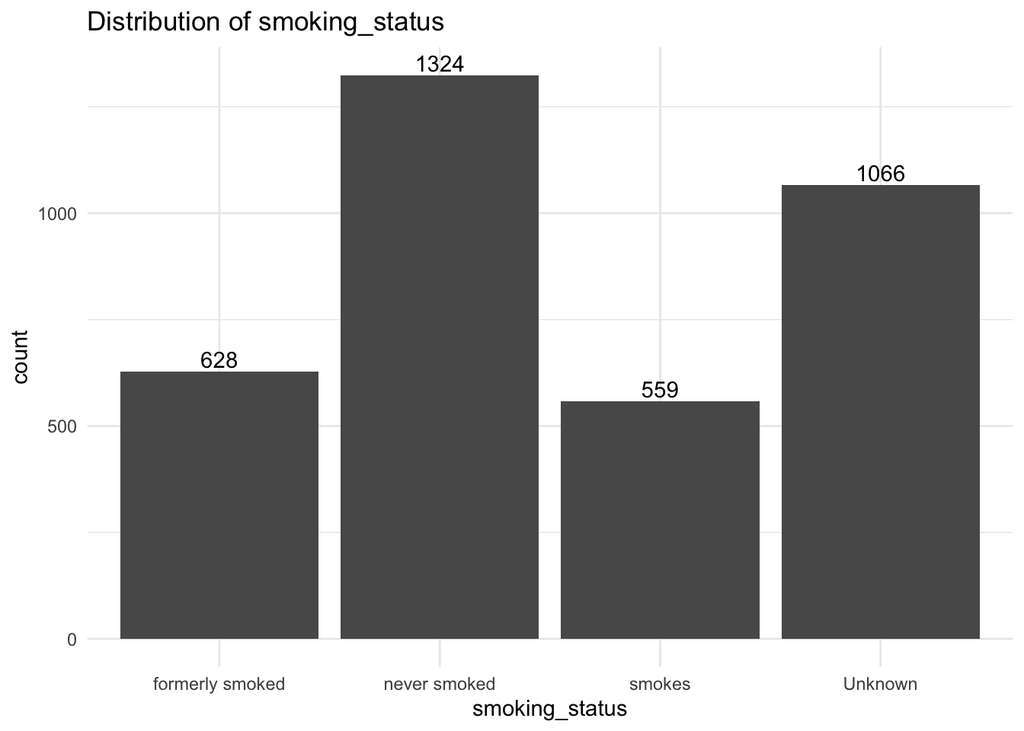

```r
ggplot(stroke_train, aes(x = smoking_status)) +
  geom_bar() +
  geom_text(
    aes(label = ..count..),
    stat = "count",
    position = position_dodge(width = 0.9),
    vjust = -0.25,
    hjust = 0.5
  ) +
  labs(
    title = "Distribution of smoking_status"
  ) +
  theme_minimal()
```

##### Distribution of `work_type`

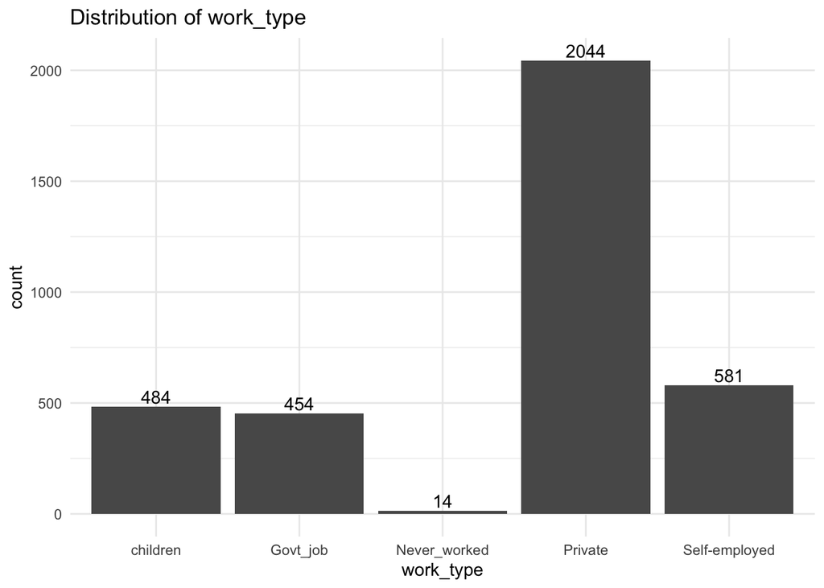

```r
ggplot(stroke_train, aes(x = work_type)) +
  geom_bar() +
  geom_text(
    aes(label = ..count..),
    stat = "count",
    position = position_dodge(width = 0.9),
    vjust = -0.25,
    hjust = 0.5
  ) +
  labs(
    title = "Distribution of work_type"
  ) +
  theme_minimal()
```

#### Relation between `gender` and `stroke`

We learned from previous readings of academic paper that the risk for stroke might differ for individuals of different gender group. Thus, we explored this relation using the training data.

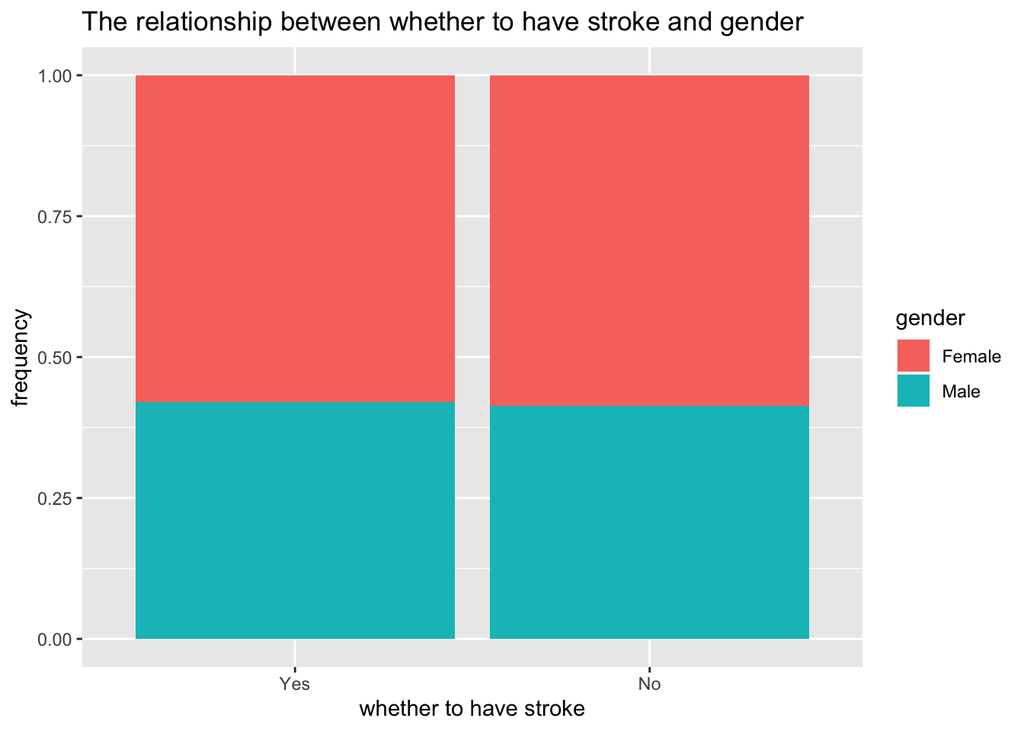

```r
ggplot(stroke_train, aes(x = stroke, fill = gender)) +
  geom_bar(position = "fill") +
  labs(
     x = "whether to have stroke",
     y = "frequency",
     title = "The relationship between whether to have stroke and gender"
  )
```

#### `stroke` and Marital & Work Status

We also explored the relation between the outcome variable `stroke` and the marital and work status of an individual.

##### `ever_married` and `stroke`

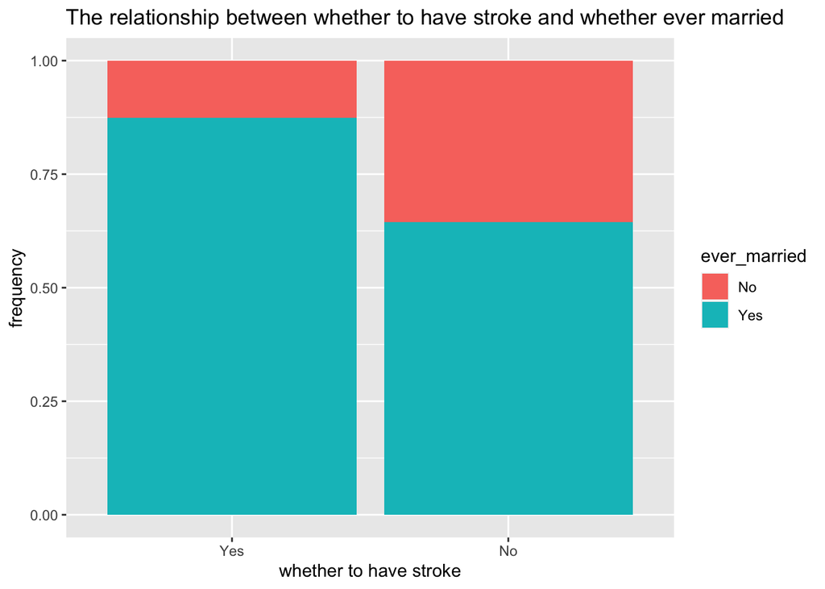

```r
ggplot(stroke_train, aes(x = stroke, fill = ever_married)) +
   geom_bar(position = "fill") +
   labs(
     x = "whether to have stroke",
     y = "frequency",
     title = "The relationship between whether to have stroke and whether ever married"
   )
```

The graph shows that the proportion of patients ever married having stroke is much higher than the proportion of patients not ever married. However, the proportion of patients ever married having stroke is higher than the proportion of patients not ever married. It might be caused by many patients have married before. Nevertheless, the huge difference between patients ever married and not ever married having stroke indicates a potential correlation between `ever_married` and `stroke`.

##### `work_type` and `stroke`

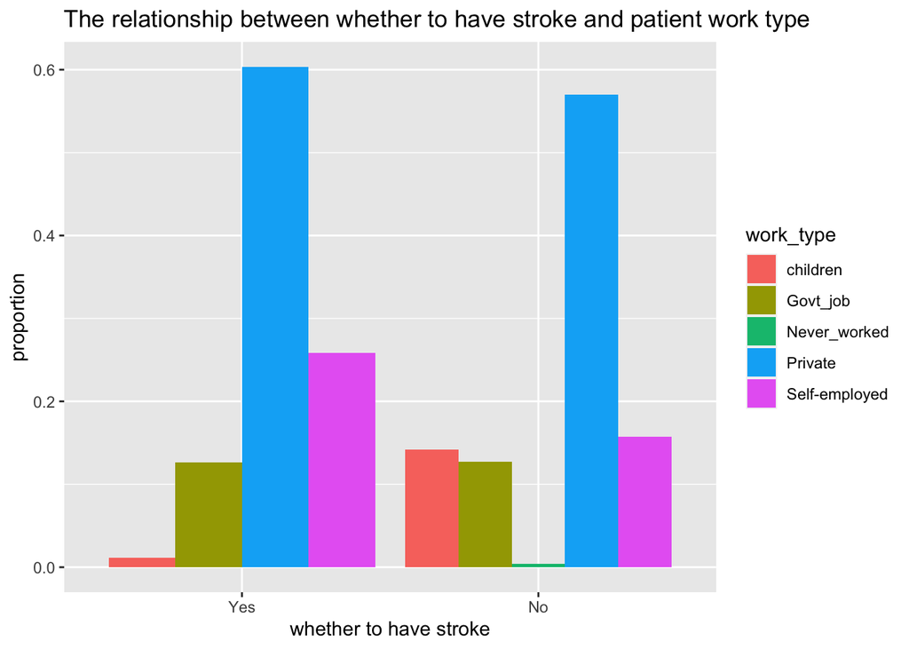

```r
stroke_train_wt <- stroke_train %>%
   group_by(stroke) %>%
   count(work_type) %>%
   mutate(wt_prop = n / sum(n))

 ggplot(stroke_train_wt, aes(x = stroke, y = wt_prop, fill = work_type)) +
   geom_col(position = "dodge") +
   labs(
     x = "whether to have stroke",
     y = "proportion",
     title = "The relationship between whether to have stroke and patient work type"
   )
```

By computing each work type proportion, the graph shows that private work type has the largest proportion in both having and not having stroke. children work type has the smallest proportion in having stroke and the third largest proportion in not having stroke. There is no people having stroke who have never worked before and there is only a tiny portion of people not having stroke who have never worked before.

## Secondary Findings

### Distribution of `residence_type`

We plotted the distribution of `residence_type` to check for class imbalance.

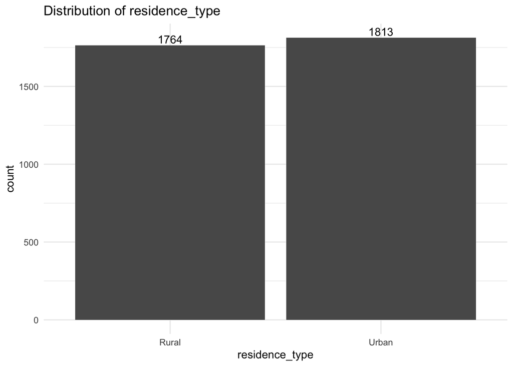

```r
ggplot(stroke_train, aes(x = residence_type)) +
  geom_bar() +
  geom_text(
    aes(label = ..count..),
    stat = "count",
    position = position_dodge(width = 0.9),
    vjust = -0.25,
    hjust = 0.5
  ) +
  labs(
    title = "Distribution of residence_type"
  ) +
  theme_minimal()
```

### `residence_type` and `stroke`

We also explored the relation between `residence_type` and the outcome variable `stroke`:

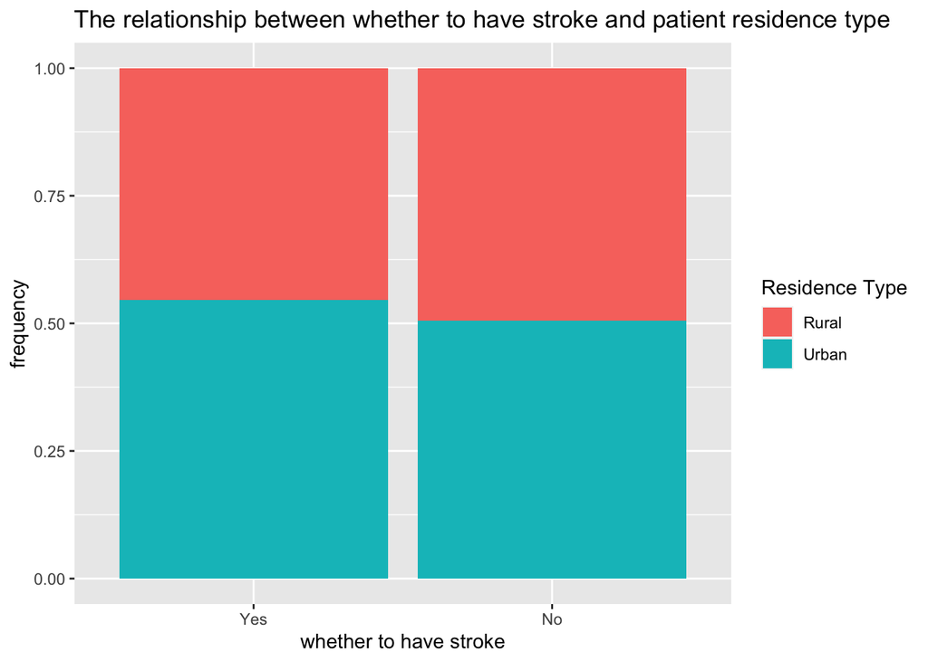

```r
ggplot(stroke_train, aes(x = stroke, fill = residence_type)) +
  geom_bar(position = "fill") +
  labs(
    x = "whether to have stroke",
    y = "frequency",
    title = "The relationship between whether to have stroke and patient residence type",
    fill = "Residence Type"
  )
```

The graph shows that there is basically no difference between whether patient lives and whether they have stroke, with people living urban area has a slightly higher chance of getting stroke.

### `smoking_status` and `gender`

We also plotted to see the proportions of people’s smoking status in each gender:

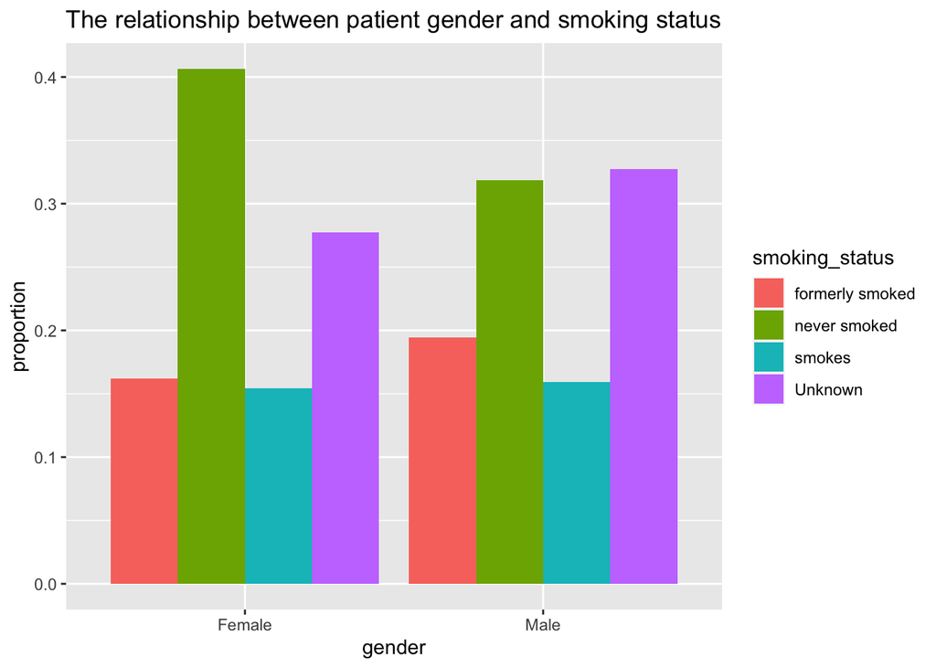

```r
stroke_stg <- stroke_train %>%
   group_by(gender) %>%
   count(smoking_status) %>%
   mutate(st_prop = n / sum(n))

 ggplot(stroke_stg, aes(x = gender, y = st_prop, fill = smoking_status)) +
   geom_col(position = "dodge") +
   labs(
     x = "gender",
     y = "proportion",
     title = "The relationship between patient gender and smoking status"
   )
```

#### `work_type` and `residence_type`

In common knowledge, residence type is associated with the type of job of an individual. Thus, we computes proportions of residence type in each work type to explore this potential relation:

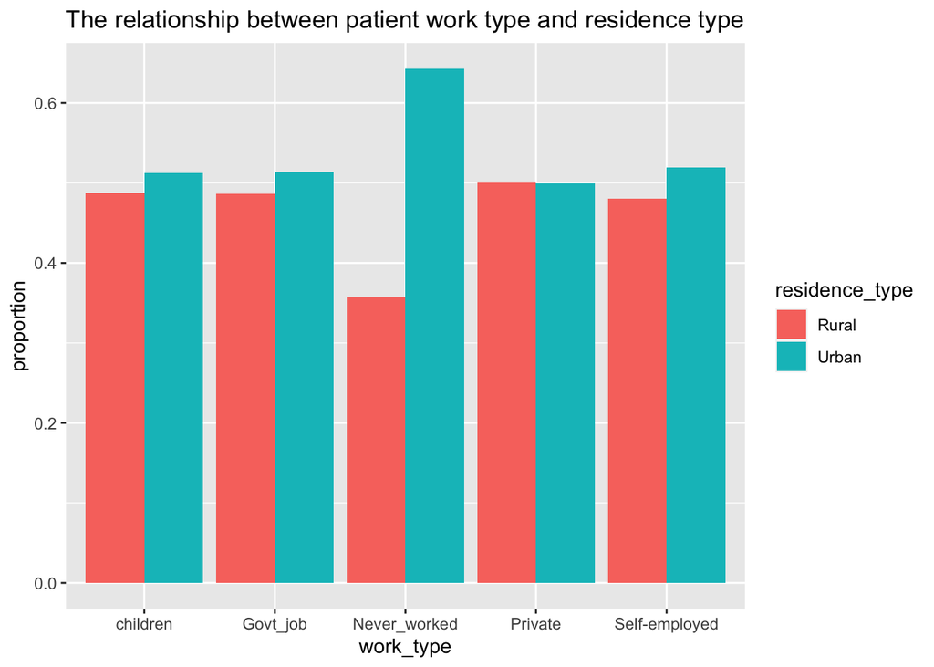

```r
 stroke_wtr <- stroke_train %>%
   group_by(work_type) %>%
   count(residence_type) %>%
   mutate(rt_prop = n / sum(n))

 ggplot(stroke_wtr, aes(x = work_type, y = rt_prop, fill = residence_type)) +
   geom_col(position = "dodge") +
   labs(
     x = "work_type",
     y = "proportion",
     title = "The relationship between patient work type and residence type"
   )
```

It can be seen that there is no strong correlation between whether patient lives and its work type. The only obvious difference is that the proportion of patients who has never worked living in urban area is much higher than living in rural area.

### Relation between `stroke` and `avg_glucose_level`

According to common understandings, the risk for stroke is often associated with the average glucose level of an indivual. Thus, we chose to explore the relation between the outcome variable `stroke` and `avg_glucose_level` using the boxplot below:

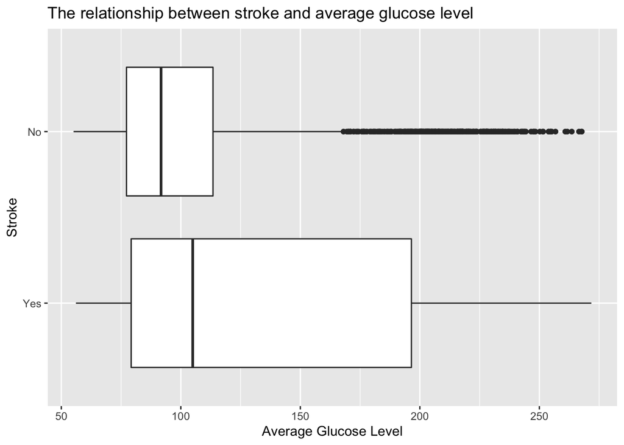

```r
# relation between `avg_glucose_level` and `stroke`
ggplot(stroke_train, aes(avg_glucose_level, stroke)) +
  geom_boxplot() +
  labs(
     x = "Average Glucose Level",
     y = "Stroke",
     title = "The relationship between stroke and average glucose level"
  )
```

As shown, for observations with value `Yes` for `stroke` the interquantile range for the distribution of the average glucose level is much wider than the distribution of the average glucose level for level `No` of the `stroke`. Also, the median average glucose level for observations with `stroke` value `Yes` is larger than the the median average glucose level for observations with `stroke` value `No`. The distribution of average glucose level values is also more right-skewed for observations with `stroke` value `No`. For observations with `stroke` value `No`, average glucose level above around 180 are considered as outliers. We can infer from the plot that, for the sample population used for collecting this data, individuals with average glucose level above 125 are more likely to get stroke.

## Conclusion and Implications

In the EDA section of our final project, we explored the distribution of the outcome variable `stroke` and the distribution of several important categorical and numeric variables using the training set of the tidied `stroke_data`. We also explored the correlation between the outcome and the predictors and the correlation between important predictors.

The analysis of missingness indicate that only one variable `bmi` contains missing values. Since the degree of missingness is very low, we plan to use bagged tree imputation on this variable in creating the recipe.

One important finding is the severe class imbalance in the outcome variable `stroke` after stratified sampling. The class imbalance is also observed in variable `ever_married`. If encountering problem in the later resampling and cross-validation process, we might need to consider using random over-sampling or under-sampling.

Moreover, there is no strong linear correlation between any pair of numeric predictors, suggesting that there is no problem with near-perfect collinearity. Numeric predictors `avg_glucose_level` and `age` are found to be closely related to `stroke`. The results suggest that, for the sample population among which the data was obtained, individuals with average glucose level above 125 and age above 60 have higher risk for getting stroke.

Thirdly, extreme right-skewness is observed in the distributions of `avg_glucose_level` and `bmi`, suggesting the need to use log-transformation in creating the recipe.

Lastly, less occurring levels are observed in categorical predictors `gender`, `smoking_status`, and `work_type`, suggesting the need to use `step_zv()` and `step_nzv()` in creating the recipe.

## GitHub Link

https://github.com/lilyyan2023/STAT301-3FinalProject